# Boris_workflow

Boris

10/13/2019

A brief description is provided above of each chunk of code

## Downloading data files

The code below helps to download the two data files needed from our Class Github repository.

```r
download.file("https://raw.githubusercontent.com/EEOB-BioData/BCB546X-Fall2019/master/assignments/UNIX_Assignment/snp_position.txt", destfile = "./snp_position.txt")

download.file("https://raw.githubusercontent.com/EEOB-BioData/BCB546X-Fall2019/master/assignments/UNIX_Assignment/fang_et_al_genotypes.txt", destfile = "./fang_et_al_genotypes.txt")
```

## Impoting data

Here, we first load the package “tidyverse” and then import the two data sets *fang_et_al_genotypes.txt* and *snp_position.txt* into the Global environment.They have been named *fang* and *snp* respectively.

```r
library(tidyverse)
rm(list = ls())  ## First, Delete all previous files in the Global environment

fang <- read_tsv("./fang_et_al_genotypes.txt" )
snp <- read_tsv("./snp_position.txt")
```

# Part I

## Data Inspection

A brief data inspection was carried out to know the number of colums and rows of both data, have a look at the first few rows and columns.

*Please note, we also looked at the structure and summary of each data set but decided to comment these lines out because the outputs were very huge.*

```r
format(object.size(fang), units = "Mb")
```

```
## [1] "22.1 Mb"
```

```r
format(object.size(snp), units = "Kb")
```

```
## [1] "350.7 Kb"
```

```r
dim(fang)
```

```
## [1] 2782  986
```

```r
dim(snp)
```

```
## [1] 983  15
```

```r
fang[1:10,1:5]
```

```
## # A tibble: 10 x 5
##    Sample_ID JG_OTU   Group abph1.20 abph1.22
##    <chr>     <chr>    <chr> <chr>    <chr>
##  1 SL-15     T-aust-1 TRIPS ?/?      ?/?
##  2 SL-16     T-aust-2 TRIPS ?/?      ?/?
##  3 SL-11     T-brav-1 TRIPS ?/?      ?/?
##  4 SL-12     T-brav-2 TRIPS ?/?      ?/?
##  5 SL-18     T-cund   TRIPS ?/?      ?/?
##  6 SL-2      T-dact-1 TRIPS ?/?      ?/?
##  7 SL-4      T-dact-2 TRIPS ?/?      ?/?
##  8 SL-6      T-dact-3 TRIPS ?/?      ?/?
##  9 SL-7      T-dact-4 TRIPS ?/?      ?/?
## 10 SL-5      T-dact-5 TRIPS ?/?      ?/?
```

```r
snp[1:10, 1:5]
```

```
## # A tibble: 10 x 5
##    SNP_ID   cdv_marker_id Chromosome Position  alt_pos
##    <chr>            <dbl> <chr>      <chr>     <chr>
##  1 abph1.20          5976 2          27403404  <NA>
##  2 abph1.22          5978 2          27403892  <NA>
##  3 ae1.3             6605 5          167889790 <NA>
##  4 ae1.4             6606 5          167889682 <NA>
##  5 ae1.5             6607 5          167889821 <NA>
##  6 an1.4             5982 1          240498509 <NA>
##  7 ba1.6             3463 3          181362952 <NA>
##  8 ba1.9             3466 3          181362666 <NA>
##  9 bt2.5             5983 4          66290049  <NA>
## 10 bt2.7             5985 4          66290994  <NA>
```

```r
class(fang)
```

```
## [1] "spec_tbl_df" "tbl_df"      "tbl"         "data.frame"
```

```r
class(snp)
```

```
## [1] "spec_tbl_df" "tbl_df"      "tbl"         "data.frame"
```

```r
#str(fang)
#str(snp)

#summary(fang)
#summary(snp)

unique(fang$Group)
```

```
##  [1] "TRIPS" "ZDIPL" "ZPERR" "ZLUXR" "ZMHUE" "ZMPBA" "ZMPJA" "ZMXCH"
##  [9] "ZMXCP" "ZMXNO" "ZMXNT" "ZMPIL" "ZMXIL" "ZMMLR" "ZMMMR" "ZMMIL"
```

```r
length(unique(fang$Sample_ID))
```

```
## [1] 2782
```

```r
length(unique(fang$Group))
```

```
## [1] 16
```

```r
length(unique(snp$SNP_ID))
```

```
## [1] 983
```

```r
length(unique(snp$Chromosome))
```

```
## [1] 12
```

## Data processing

The first part of data processing consisted of filtering the three groups of maize and teosinte then transposing each to have the snps as rows.

```r
Maize_transposed <- filter(fang, Group %in% c("ZMMLR", "ZMMMR", "ZMMIL")) %>%
  select(-JG_OTU, -Group) %>% column_to_rownames(., var = "Sample_ID") %>% t() %>%
  as.data.frame() %>% rownames_to_column(., var = "SNP_ID")

Teosinte_transposed <- filter(fang, Group %in% c("ZMPBA", "ZMPIL", "ZMPJA")) %>%
  select(-JG_OTU, -Group) %>% column_to_rownames(., var = "Sample_ID") %>% t() %>%
  as.data.frame() %>% rownames_to_column(., var = "SNP_ID")
```

Next, we filtered out only the 3 columns of interest in the snp_position data file. Then we merged it with transposed data for maize and teosinte.

*Please note, SNPs with unknown and multiple positions and chromosomes were filtered out.*

```r
snp_formatted <- snp %>% select(SNP_ID, Chromosome, Position)

Maize_merged <- merge(snp_formatted, Maize_transposed ) %>%
  filter(., Position != "multiple",  Chromosome != "unknown")

Teosinte_merged <- merge(snp_formatted, Teosinte_transposed) %>%
  filter(., Position != "multiple",  Chromosome != "unknown")
```

After creating the merged files, we used the *mutate_all* and *gsub* functions to replace all the “?” by “-” fothe both maize and tesointe.

```r
Maize_replaced <- Maize_merged %>% mutate_all(function(x) gsub("\\?", "\\-",x))
Teosinte_replaced <- Teosinte_merged %>% mutate_all(function(x) gsub("\\?", "\\-",x))
```

## File creation

For a proper oganization of the files, we created two separate **directories** one for maize and one for teosinte. The code is as follows:

*Please note, if this repository has been cloned or forked, no need to run this chunck as the directories already exist. So will be the warnings message*

```r
dir.create("./maize_files")
dir.create("./teosinte_files")
```

Having created the directories, we then used a *for loop* to generate all the 40 files at once and written in their respective directories. Below is the code:

```r
for (i in 1:10) {

  m1 <- Maize_merged %>% filter(., Chromosome == i[1]) %>% arrange(.,as.numeric(Position))
  m2 <- Maize_replaced %>% filter(., Chromosome == i[1]) %>% arrange(.,desc(as.numeric(Position)))

  write_tsv(m1, file.path("./maize_files/", paste("Maize_chr", i[1], "increasing.txt", sep = "_")))
  write_tsv(m2,  file.path("./maize_files/", paste("Maize_chr", i[1], "decreasing.txt", sep = "_")))

  t1 <- filter(Teosinte_merged, Chromosome == i[1]) %>% arrange(., as.numeric(Position))
  t2 <- filter(Teosinte_replaced, Chromosome == i[1]) %>% arrange(., desc(as.numeric(Position)))

  write_tsv(t1, file.path("./teosinte_files/", paste("Teosinte_chr", i[1], "_increasing.txt", sep = "_")))
  write_tsv(t2, file.path("./teosinte_files/", paste("Teosinte_chr", i[1], "_decreasing.txt", sep = "_")))

}
```

# Part II

## Data processing

Some further data processing was done prior to visualization. Here, we transposed and merged the entire *fang_et_al_genotype.txt* file with the *snp_position.txt*.

*Please note, here too, SNPs with unknown and multiple positions and chromosomes were filtered out.*

```r
Fang_transposed <- fang %>% select(-JG_OTU, -Group) %>% column_to_rownames(., var = "Sample_ID") %>%
  t() %>% as.data.frame() %>% rownames_to_column(., var = "SNP_ID")

Fang_merged <- merge(snp_formatted, Fang_transposed ) %>%
  filter(., Position != "multiple",  Position != "unknown")
```

## Data visualization

Here, we created a bargraph to plot the total number of SNPs per chromosome using *ggplot* and its component *geom_bar*

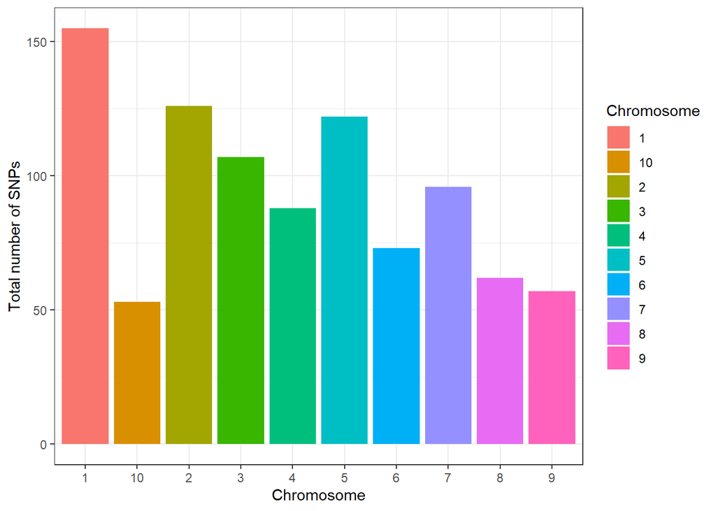

```r
ggplot(Fang_merged, aes(x= Chromosome)) + geom_bar(aes(fill = Chromosome)) + theme_bw() + labs(x = "Chromosome", y = "Total number of SNPs")
```

Next, we created a density plot to show the distribution of SNPs on chromosome using *ggplot* and its components *geom_density* and *facet_wrap*

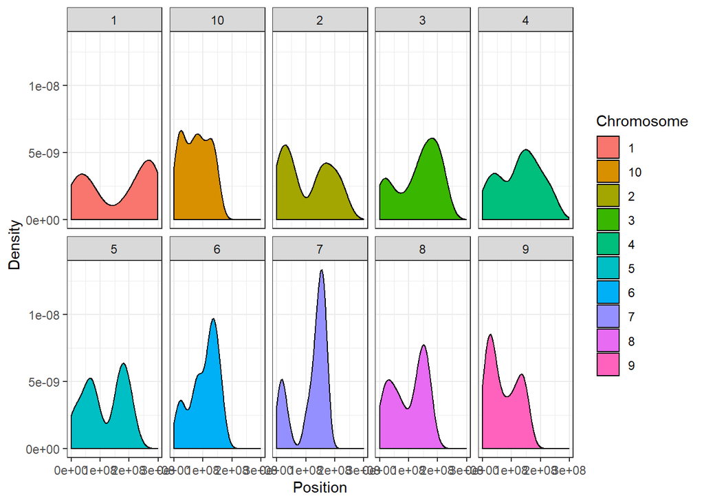

```r
ggplot(Fang_merged, aes(x= as.numeric(Position))) + geom_density(aes(fill = Chromosome)) + facet_wrap(~ Chromosome, nrow = 2, ncol = 5) + theme_bw() + labs(x = "Position", y = "Density")
```

## Further data processing

The original *fang_et_al_genotypes.txt* data was not tidy. So, I we first made it tidy using *pivot_long* function. Next, we used *mutate* and *ifelse* to substitute the genotypic sequence by homo, hetero and missing.

```r
tidy_fang <- fang %>% select(-JG_OTU) %>%
  pivot_longer( -Sample_ID:-Group, names_to = "SNP_ID", values_to = "Sequence")

tidy_fang <- tidy_fang %>%
  mutate(new_sequence = ifelse(Sequence %in% c("A/A","T/T","C/C","G/G"), "Homozygous",
  ifelse(Sequence == "?/?", "Missing","Heterozygous")))
```

## Data visualization

Here, we created a stacked bargraph to show the standardized proportion of homozygot, heterozygot and missing sites for all the 2782 samples.

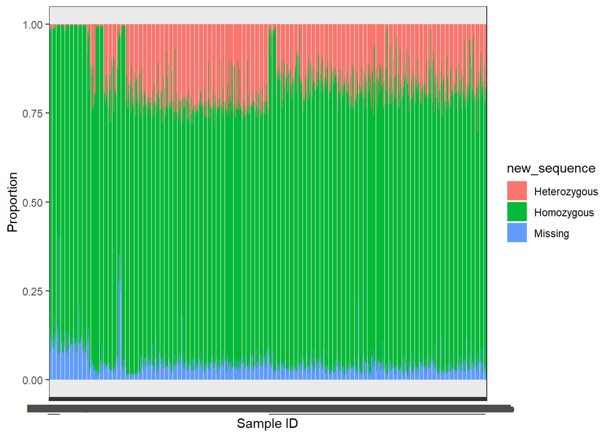

```r
ggplot(tidy_fang, aes(x = Sample_ID, fill = new_sequence)) + geom_bar(position = "fill") +
  theme_bw() + labs(x = "Sample ID", y = "Proportion")
```

Another stacked bargraph was created to show the standardized proportion of homozygot, heterozygot and missing sites for all the 16 groups.

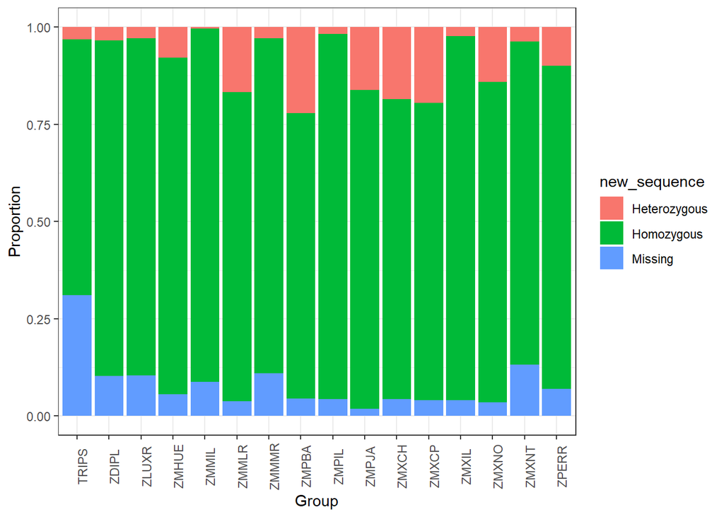

```r
ggplot(tidy_fang, aes(x = Group , fill = new_sequence)) + geom_bar(position = "fill") +
  theme_bw() + theme(axis.text.x = element_text(angle = 90))+ labs(y = "Proportion")
```

### My own visualization

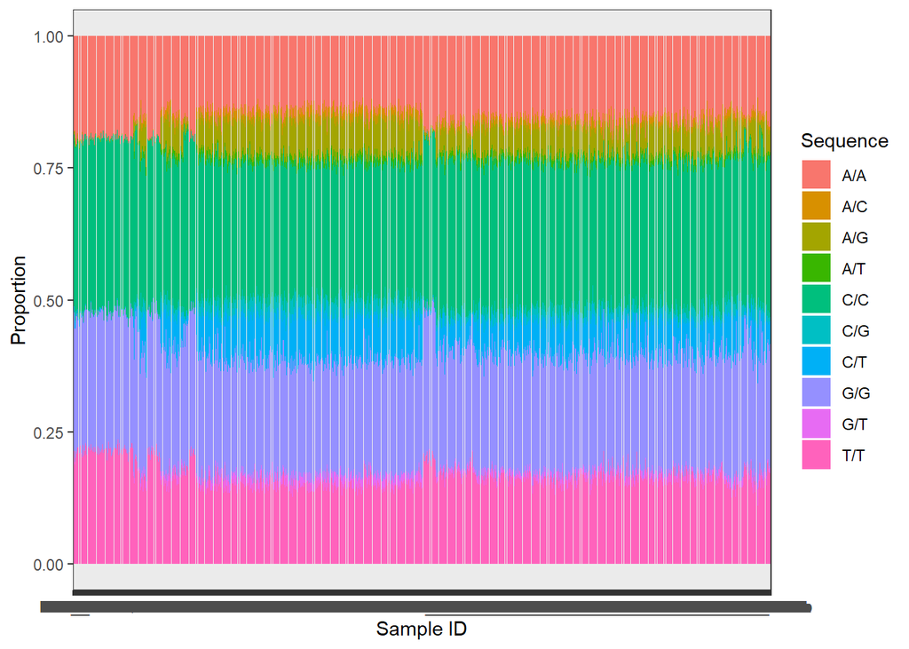

```r
ggplot(filter(tidy_fang, Sequence != "?/?") , aes(x = Sample_ID, fill = Sequence)) +
  geom_bar(position = "fill") + theme_bw() + labs(x = "Sample ID", y = "Proportion")
```

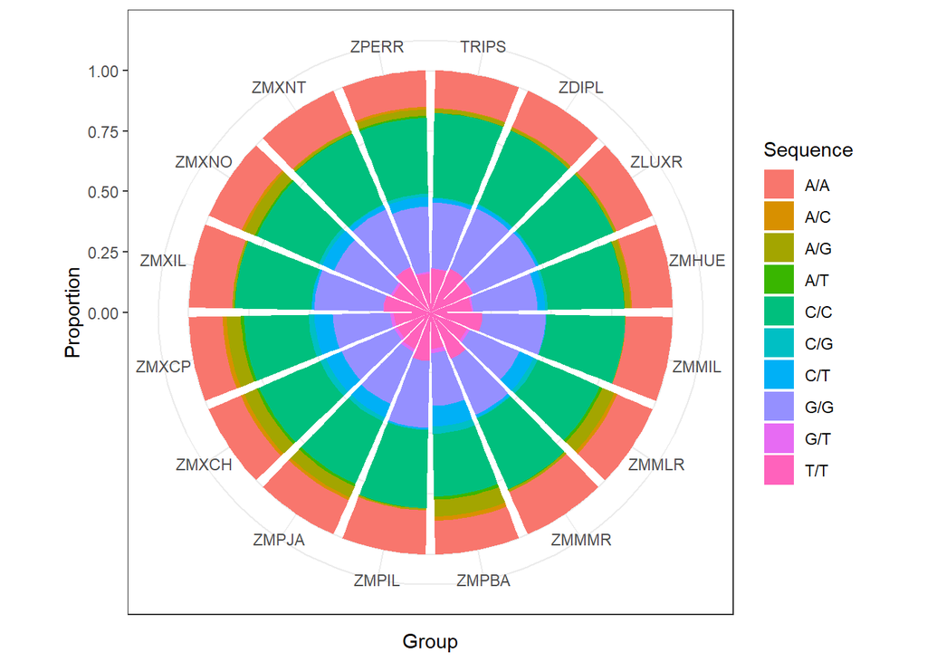

```r
ggplot(filter(tidy_fang, Sequence != "?/?") , aes(x = Group, fill = Sequence)) +
  geom_bar (position = "fill") + coord_polar() +theme_bw() + labs(y = "Proportion")
```